# Epic Cosmos vector-borne diseases

## Trends and maps

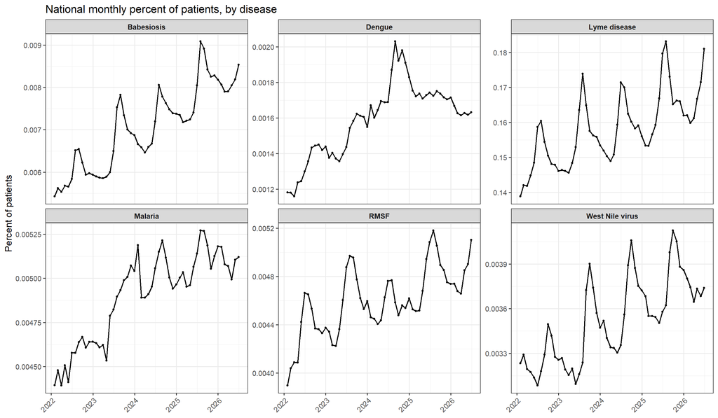

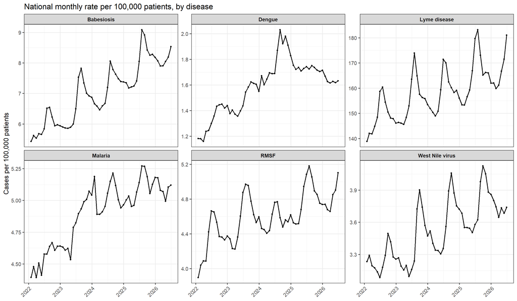

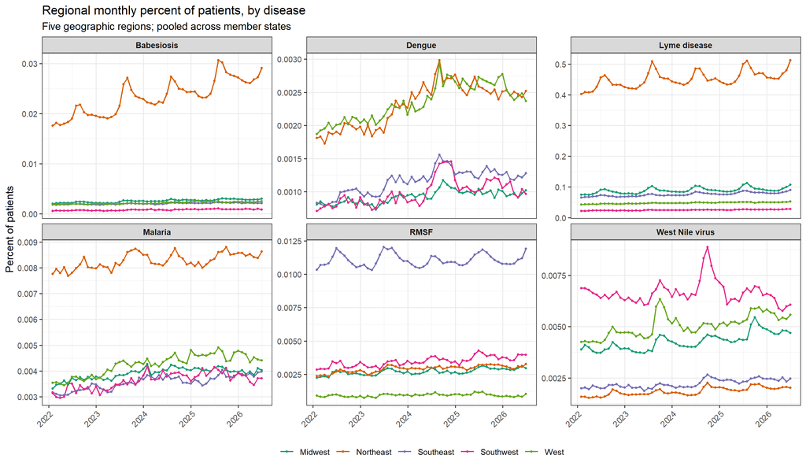

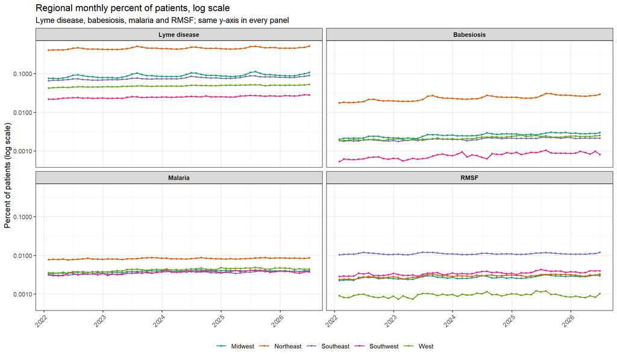

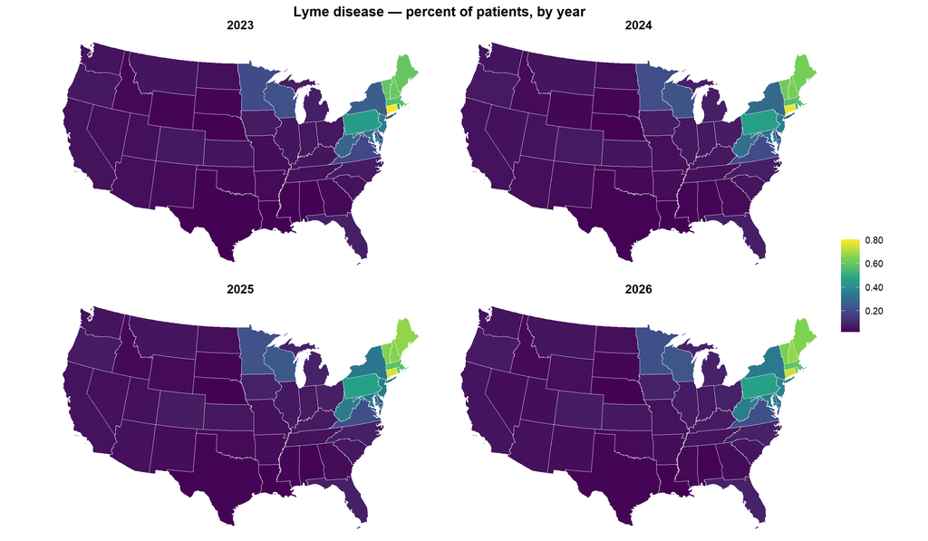

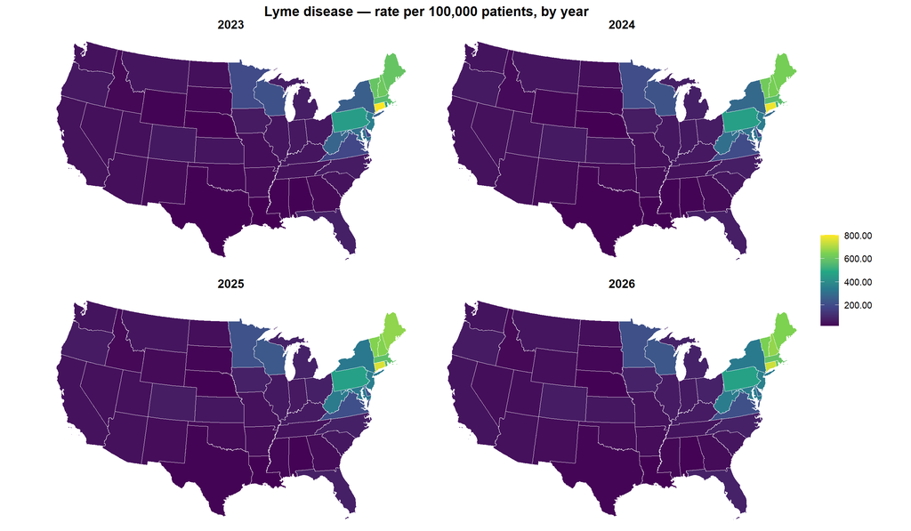

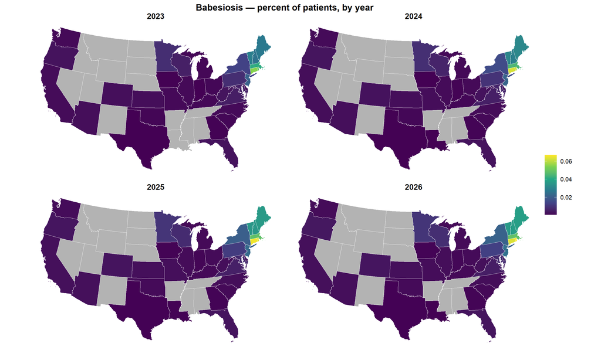

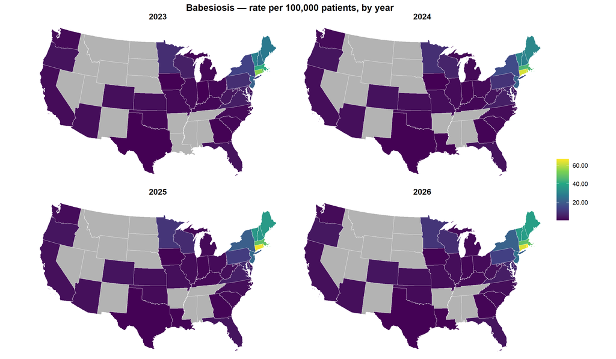

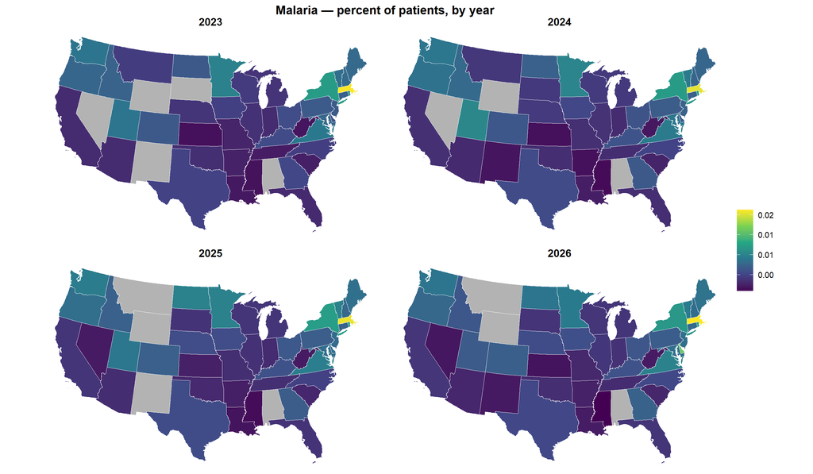

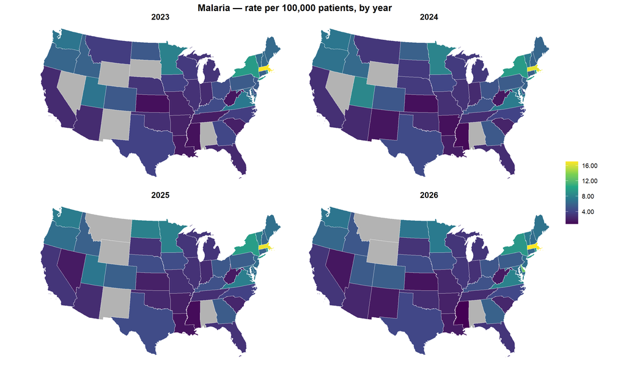

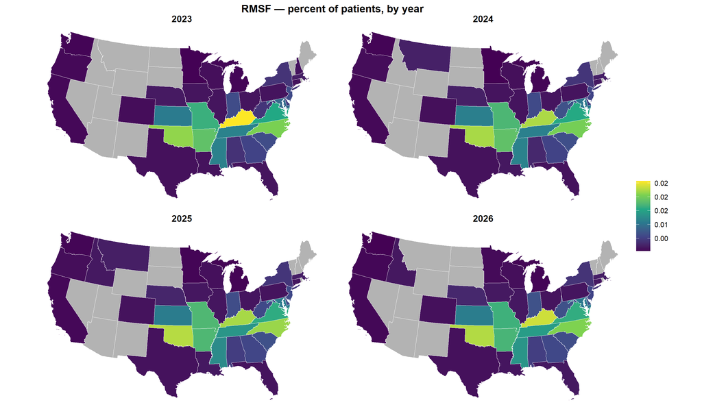

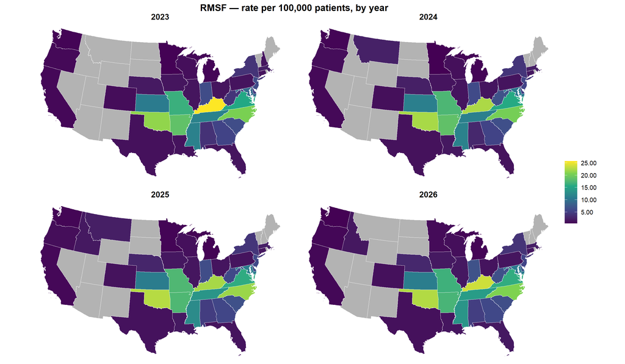

[4 more figures not shown]

## New cases problem list

Patients with a **new** (first-time) diagnosis, using Epic’s new-case measure on the problem list, from this source (SlicerDicer session 2861722, `standard/data_new_cases.csv.gz`). Same population base and denominator as the tab above, but the numerator counts only first-time diagnoses, so it is a subset of the all-diagnosis counts. See the *New cases pop filter* tab for the alternative definition. Most state-month cells for the rarer diseases are suppressed (imputed as 5), so the national and regional panels are the most reliable.

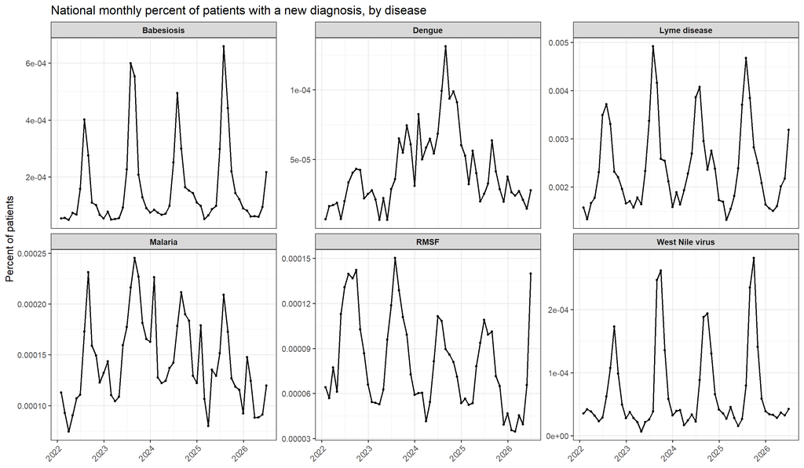

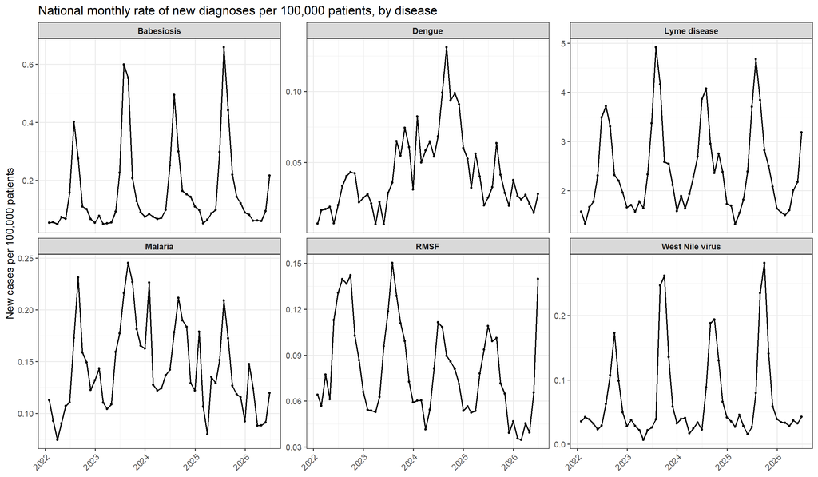

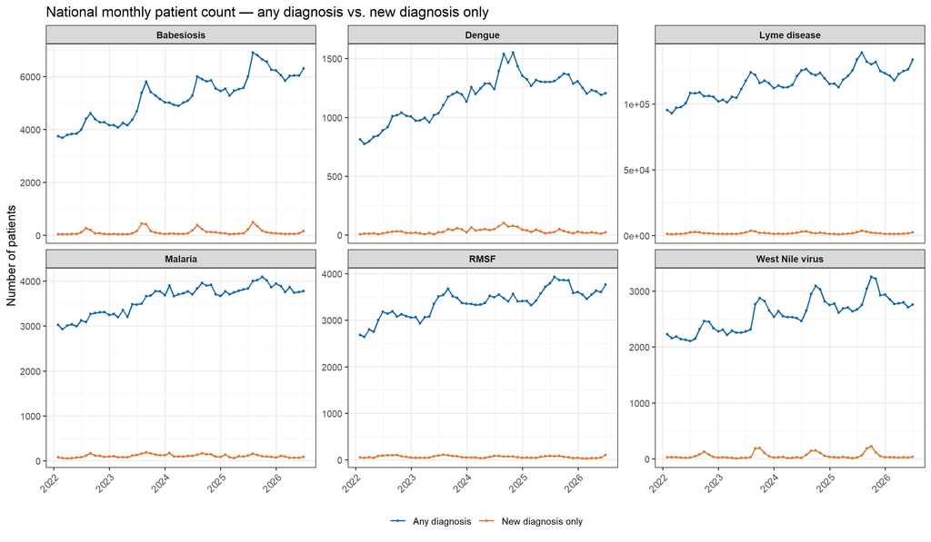

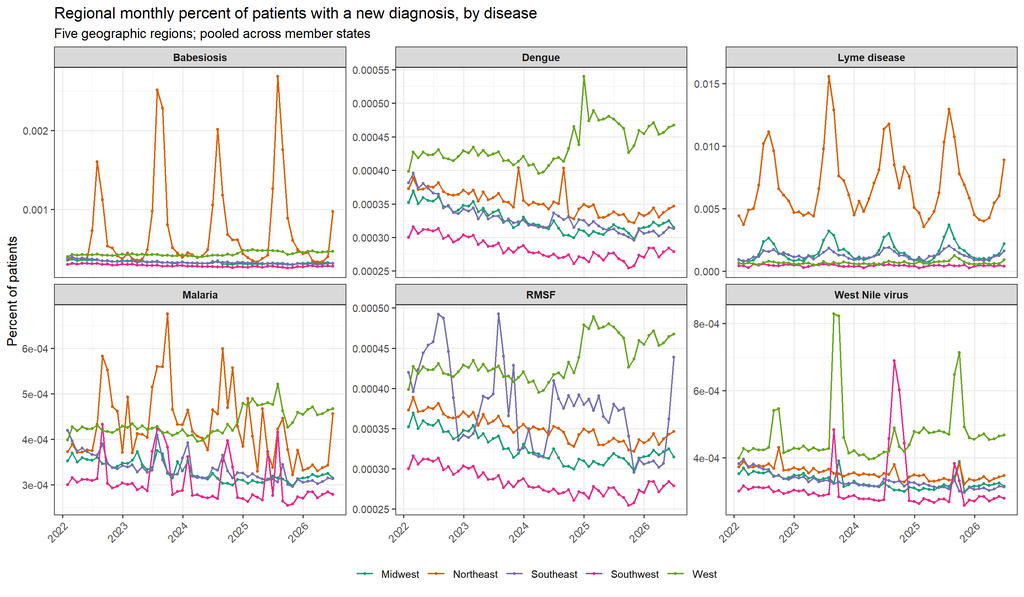

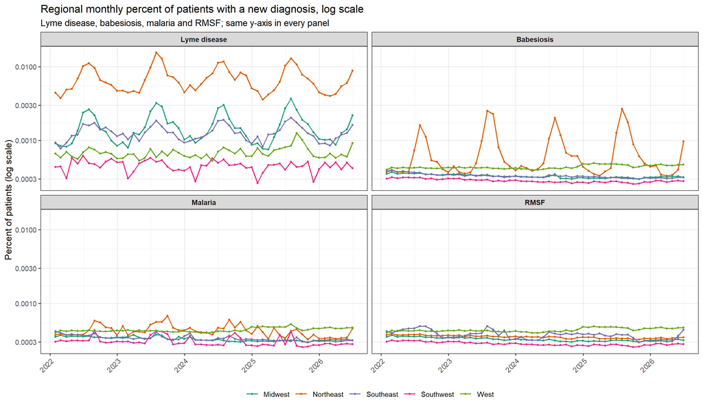

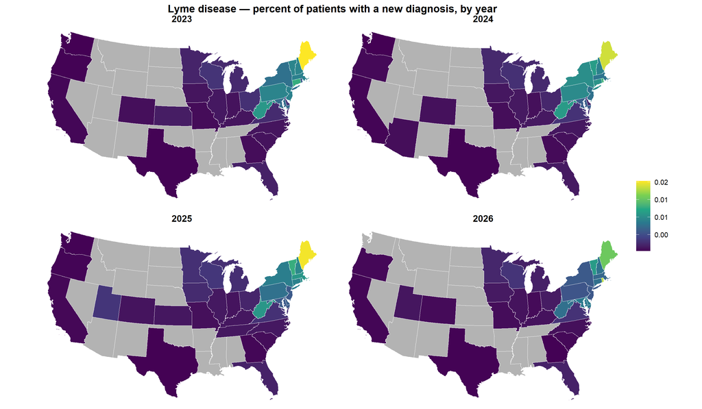

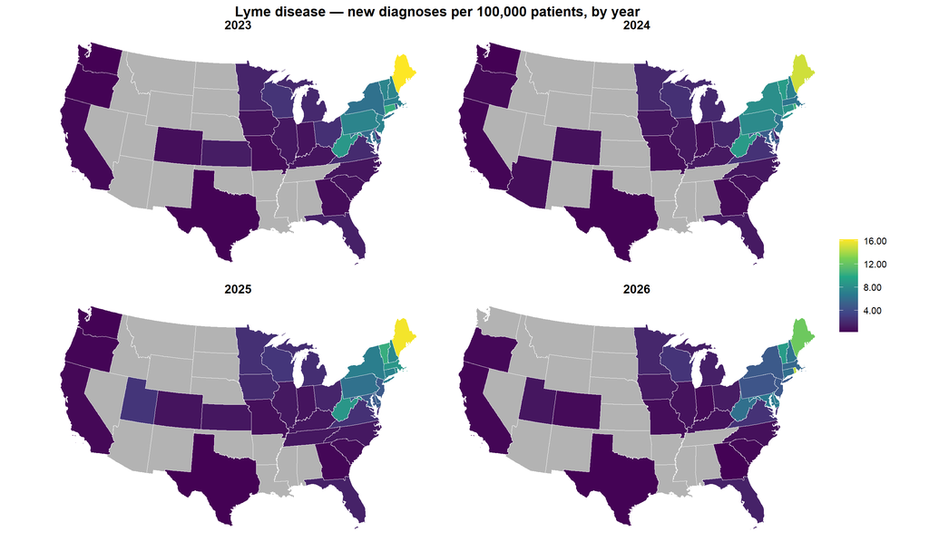

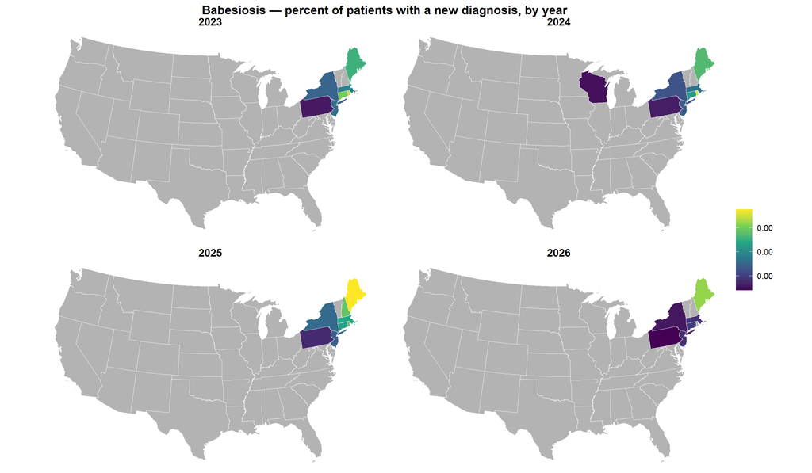

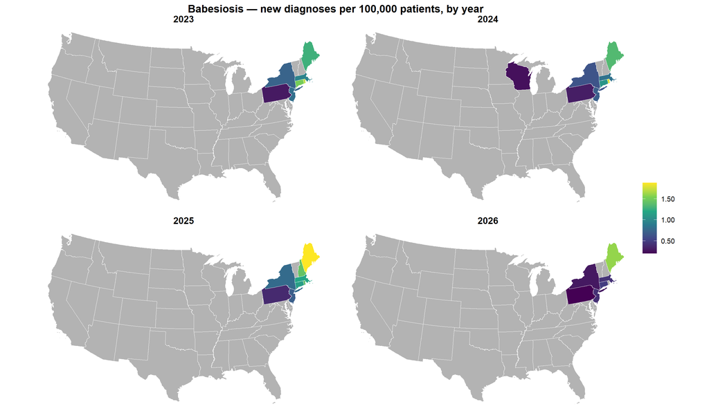

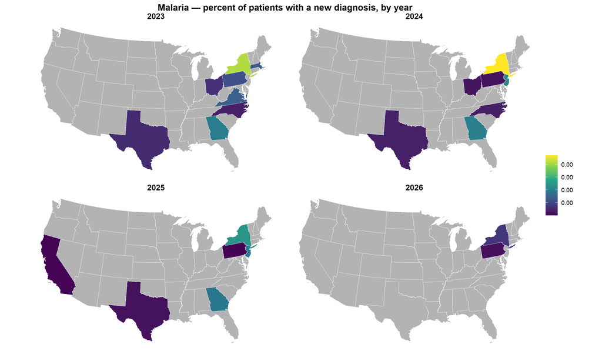

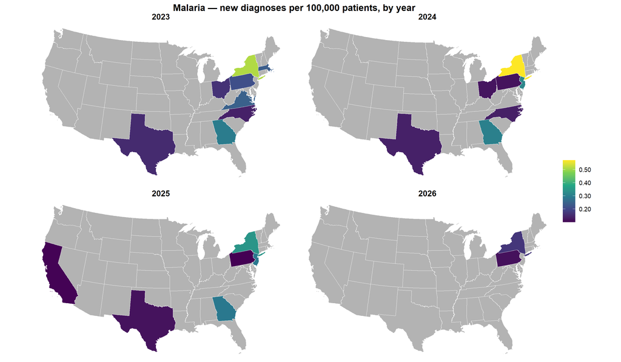

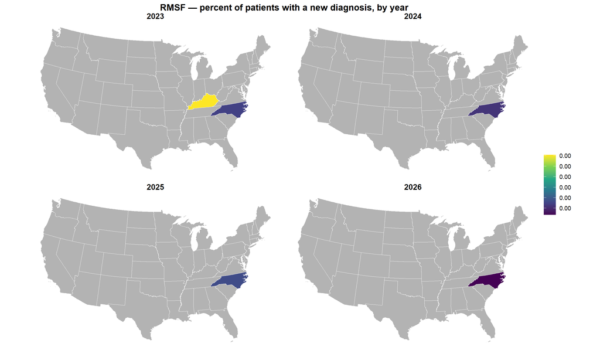

[5 more figures not shown]

## New cases pop filter

Patients with a **new** (first-time) diagnosis, defined with a **population filter** (SlicerDicer session 2863644, `standard/data_new_cases_pop_filter.csv.gz`, annual, 2022-2025; the partial 2026 year is dropped). The population is restricted to patients with a diagnosis of one of the six diseases that was not preceded by the same diagnosis within 6 months. The denominator is therefore the number of patients **in that filtered population**, not all Epic patients, so the percents below are shares among patients with a new vector-borne diagnosis (not comparable to the percents in the other tabs). A patient can have more than one disease, so disease counts can sum to more than the denominator. Most state-year cells for the rarer diseases are suppressed (imputed as 5); the national and regional panels are the most reliable.

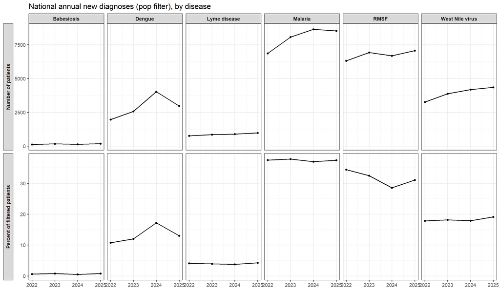

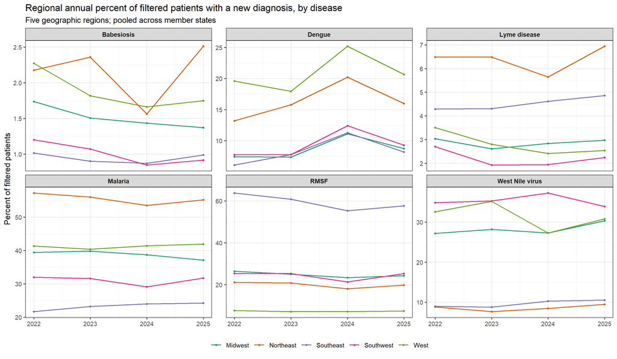

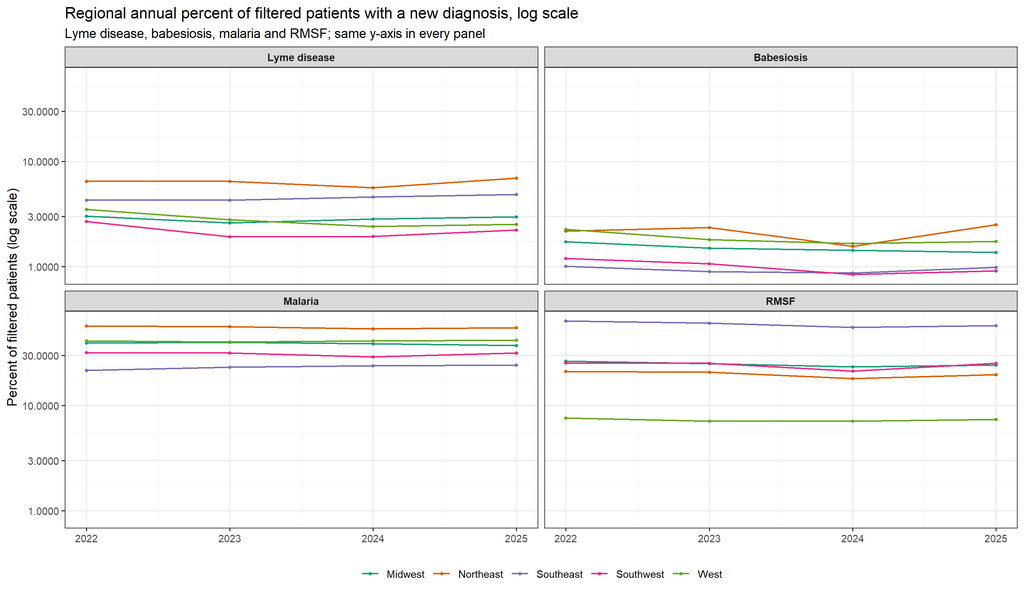

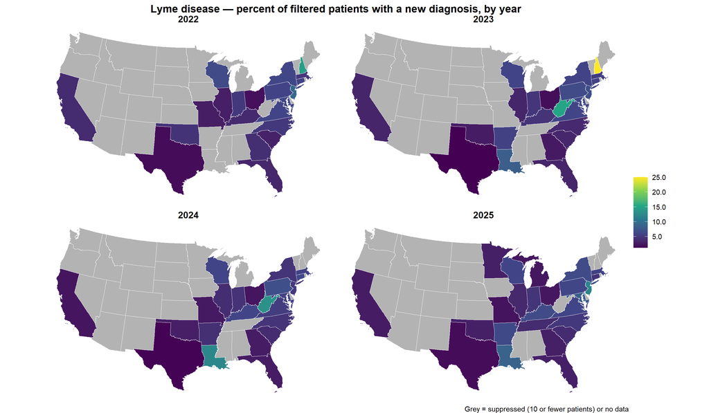